# Coursera | Data Science | Practical Machine Learning Peer-graded Assignement

Charbel Lahoud

7th September 2019

## Introduction

This project is based on the **Weight Lifting Exercise Dataset** available from the website here: http://groupware.les.inf.puc-rio.br/har

6 participants were asked wereto perform barbell lifts correctly and incorrectly in 5 different ways.  
**The goal of this project is to predict the manner in which they did the exercise**  
In order to do so, we will the use data from accelerometers on the belt, forearm, arm, and dumbell of 6 participants.

## Getting the data

To keep this report short, the exploration of the data was not included in this report

```r
library(ggplot2)
library(caret)
library(fscaret)
library(randomForest)
library(e1071)
library(readr)

url_train <- "https://d396qusza40orc.cloudfront.net/predmachlearn/pml-training.csv"
url_test <- "https://d396qusza40orc.cloudfront.net/predmachlearn/pml-testing.csv"
if (!file.exists("training_data.csv")) {download.file(url_train,destfile="training_data.csv")}
if (!file.exists("testing_data.csv")) {download.file(url_test,destfile="testing_data.csv")}

training<-read.csv("training_data.csv",na.strings = c("NA", "#DIV/0!", ""))
testing <- read.csv("testing_data.csv",na.strings = c("NA", "#DIV/0!", ""))
```

## Splitting the data

###Removing columns that contains NA values and irrelevant variables

```r
training <- training[, which(colSums(is.na(training)) == 0)]
testing <- testing[, which(colSums(is.na(testing)) == 0)]
training <- training[,-c(1:7)] ##the first 7 columns are variables that has no relationship with "class"
testing <- testing[,-c(1:7)]
```

###Partioning the training set into training and crossvalidation datasets

```r
set.seed(888)
training = data.frame(training)
inTrain <- createDataPartition(training$classe, p=0.70, list=FALSE)
train <- training[inTrain, ]
validation <- training[-inTrain, ]
```

##Building model and cross validation

###Modelling with regression tree (“rpart”)

```r
fit1 <- train(classe ~ ., method="rpart", data=train)
val1 <- predict(fit1, validation)
cm_fit1 <- confusionMatrix(validation$classe, val1)
accuracy_fit1 <- cm_fit1$overall['Accuracy']
accuracy_fit1
```

```
##  Accuracy
## 0.5612574
```

###Modelling with random forest (“rf”)

I’ve experienced very slow performance to run this model. That’s why I start by enabling parallel processing

```r
## Configure parallel processing
library(parallel)
library(doParallel)
cluster <- makeCluster(detectCores() - 1) # convention to leave 1 core for OS
registerDoParallel(cluster)
## Configure trainControl object
fitControl <- trainControl(method = "cv",
                           number = 5,
                           allowParallel = TRUE)
## Now, we can train the model with the parallel processing
fit2 <- train(classe ~ ., method="rf", data=training, trControl = fitControl)
## De-register parallel processing cluster
stopCluster(cluster)
registerDoSEQ()
## Now we continue the study
val2 <- predict(fit2, validation)
cm_fit2 <- confusionMatrix(validation$classe, val2)
accuracy_fit2 <- cm_fit2$overall['Accuracy']
accuracy_fit2
```

```
## Accuracy
##        1
```

###Modelling with boosted trees (“gbm”)

```r
fit3 <- train(classe ~ ., method="gbm", data=train,trControl=trainControl(method = "repeatedcv", number = 5, repeats = 1),verbose=FALSE)
val3 <- predict(fit3, validation)
cm_fit3 <- confusionMatrix(validation$classe, val3)
accuracy_fit3 <- cm_fit3$overall['Accuracy']
accuracy_fit3
```

```
##  Accuracy
## 0.9634664
```

### Comparing all the 3 models

```r
data.frame(Models=c("rpart","rf","gbm"),Accuracy=c(accuracy_fit1,accuracy_fit2,accuracy_fit3))
```

```
##   Models  Accuracy
## 1  rpart 0.5612574
## 2     rf 1.0000000
## 3    gbm 0.9634664
```

##Prediction We used the random forest model for prediction

```r
pred <- predict(fit2, newdata=testing)
pred
```

```
##  [1] B A B A A E D B A A B C B A E E A B B B
## Levels: A B C D E
```

##Appendix

###Plotting decision tree(method=“rpart”)

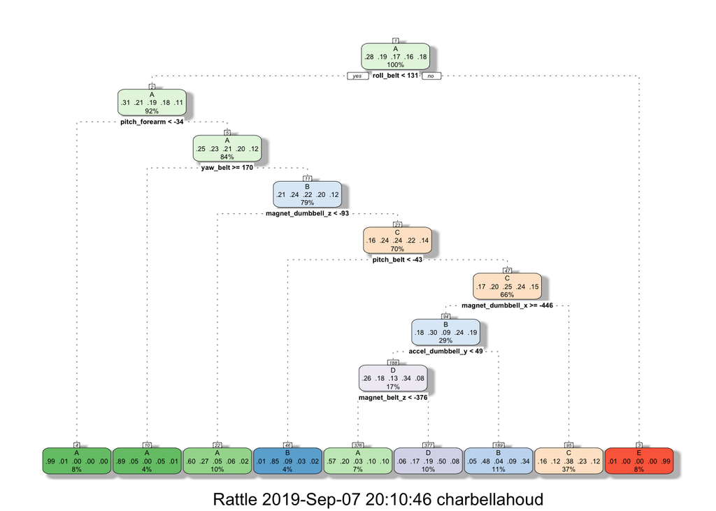

[output not shown]

[output not shown]

[output not shown]